# WNBA Player Archetypes & Comparisons

Amor Ai[^1]

Andrew Noecker[^2]

Mykalyster Homberg[^3]

July 22, 2022

[figure not shown]

# Introduction:

Over the past decade, with the growing influence of social media and heightened popularity of global stars, interest in women’s sports has skyrocketed. However, even with the appearance of high-profile campaigns for equity in sports<sup>1</sup>, it has nonetheless been difficult to cultivate an audience and build a market for women’s sports when they receive minimal media coverage compared to their male counterparts<sup>2</sup>. Although major tournaments, such as the WNBA Finals, are strong pulls for fans, the lack of nationally televised games and limited marketing budgets to showcase the players throughout the year has been a barrier for sports fans — especially established NBA fans — to consistently engage with the WNBA even when they’re interested. Furthermore, although we have seen how statistics can fuel sports passion and storytelling, it was only recently that data and advanced statistics for the WNBA became easily accessible to the public<sup>3</sup>. Therefore, we seek to not only promote sustained fan engagement and interactions with the WNBA, we hope to also provide better and more accessible statistics of the players as well.

**Our project aims to make the following contributions, which will be displayed in a public facing Shiny App:**

> 1. Develop archetypes of current WNBA players based on each player’s tendencies, abilities, and overall statistics
>    - Conduct archetype exploration on NBA players using the same variables to discover similarities and differences in the type of players between the respective leagues
> 2. Draw comparisons between WNBA players to NBA players
>    - Each WNBA player (that has played significant minutes/games) will be matched with 3-5 similar NBA players based SOLELY on their play style

Ultimately, we believe that labeling each WNBA player with an archetype and developing an NBA player comparison can boost year-round engagement and bring the WNBA into the spotlight and keep them there for years to come.

### Shiny app inspiration:

[figure not shown]

# Data:

To define player archetypes in the WNBA and compare WNBA players to NBA players, data must be gathered on a seasonal basis. Using Basketball Reference<sup>4</sup>, player statistics were gathered dating back to 2018 (the first year WNBA play-by-play and shot location became available). Relevant variables included:

- **Per 100 possession statistics** such as:
  - Points, rebounds, assists
  - Turnovers, field goals made, field goals attempted
- **Advanced statistics** designed to demonstrate player tendencies and efficiency such as:
  - PER, Usage Rate, Win Shares
- **Play by play statistics** such as:
  - Type of turnover (bad pass, lost ball)
  - Foul information (fouls drawn, fouls committed)
- **Shooting tendency** data such as:
  - Percentage of shots at the rim, percentage of shots from 3
  - Percentage of shots that were assisted

This data allows both play style and effectiveness to be evaluated and considered when developing player archetypes and subsequently creating player comparisons between WNBA players and NBA players.

*Cleaning the WNBA all stats dataset:*

- Gathered data from the 2018 - 2021 seasons
- Players with minutes per game < 10 and games played < 5 were dropped to remove players who’ve played an insignificant amount of time
  - Roughly 25% of players were removed based on an ECDF graph
- TOT rows were eliminated due to BBallRef miscalculations of TOT rows
  - If a player played with multiple teams over the course of a season, we kept their statistics from teams on which they played more minutes
- Re-labeled all player positions to either “G”, “F”, or “C” for guards, forwards, and centers respectively

*Cleaning the NBA all stats dataset:*

- Gathered data from the 2018 - 2021 seasons
- Players with less than 100 total minutes played were dropped to remove players who’ve played an insignificant amount of time
  - Roughly 10-15% of players were removed based on minutes played
- Removed 3 outliers who did not have a TOT column
- Re-labeled all player positions to either “PG”, “SG”, “SF”, “PF”, or “C” for point guards, shooting guards, small forwards, power forwards, and centers respectively

## EDA

Before modeling or clustering, the distributions of variables within the WNBA dataset were examined to better understand the relationships that are present:

**Position Distribution:**

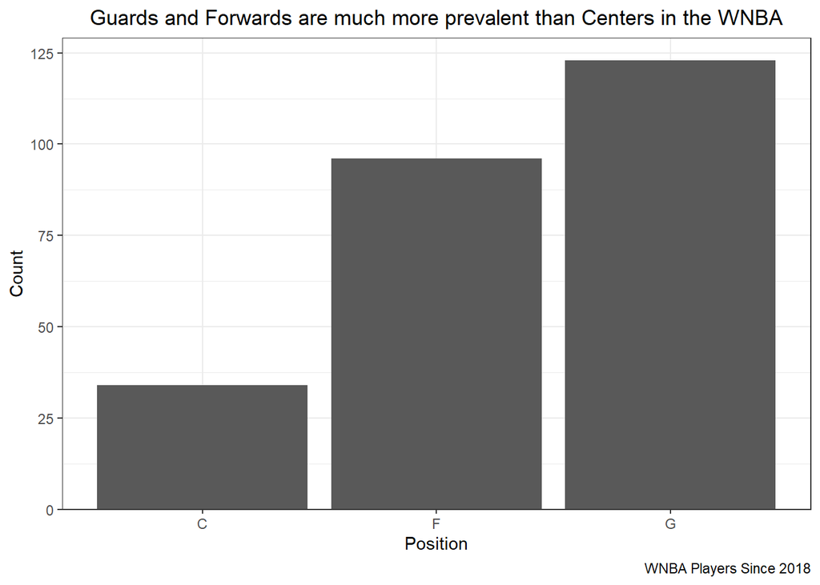

**Distribution of Minutes Per Game across WNBA Players:**

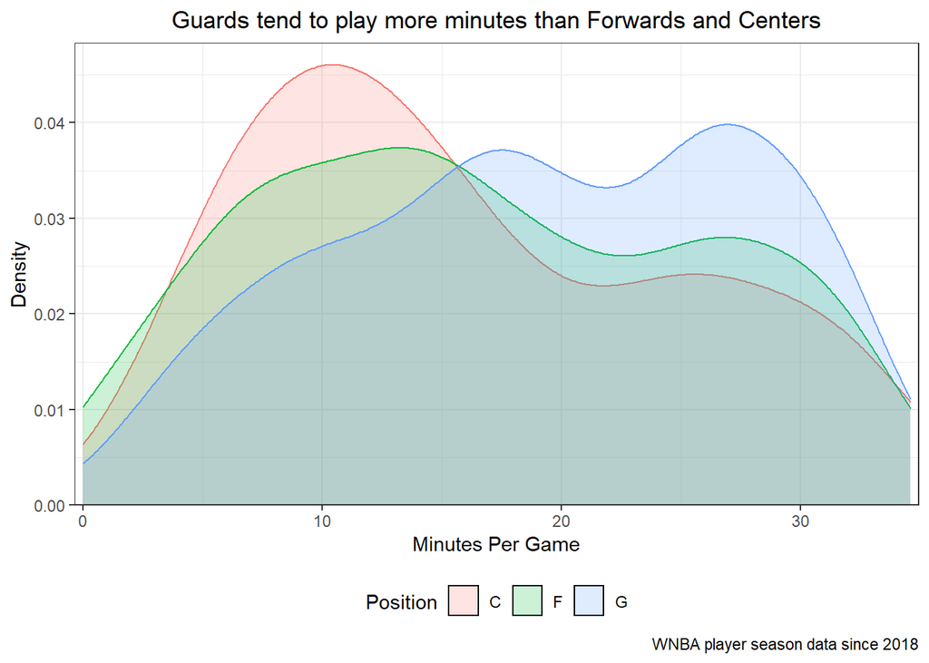

**Shot distance:**

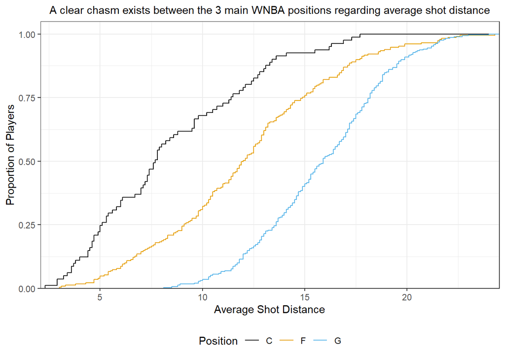

**Field Goals:**

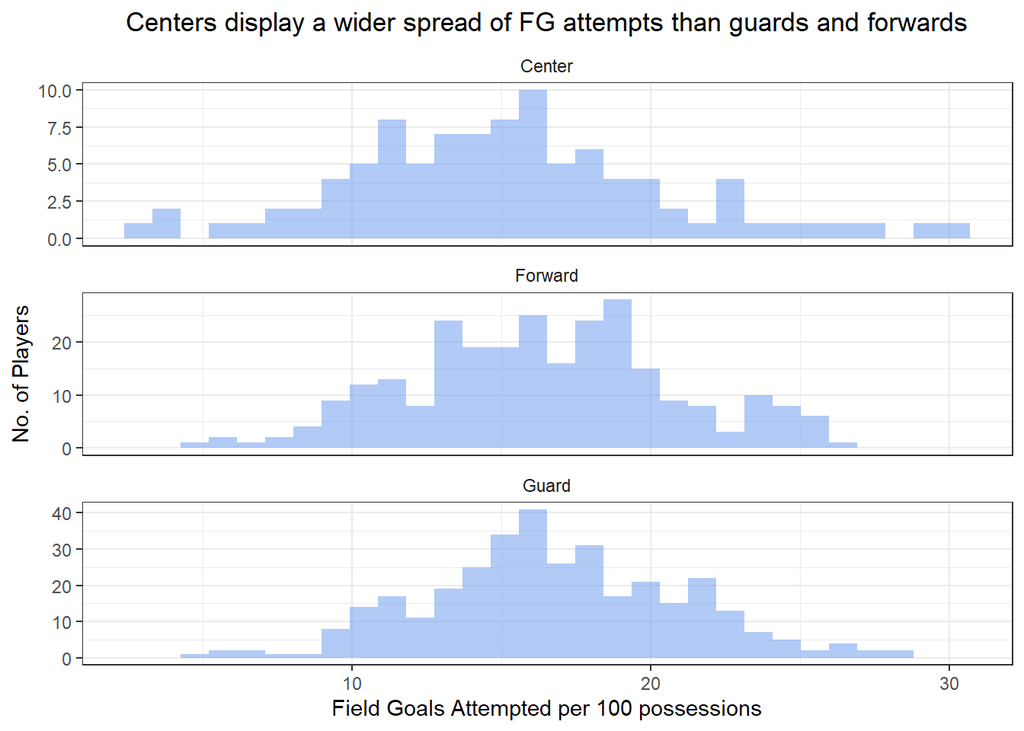

**Assist & Block percentage:**

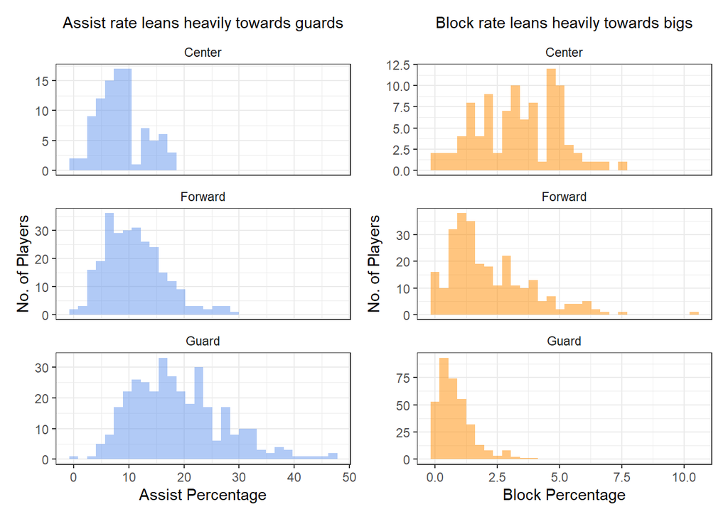

# Methods:

## 1. Developing Archetypes:

To choose which subset of variables were important in determining the archetypes, principal component analysis (PCA) was used to reduce the dimensionality of the feature space.

### PCA:

- Filtering WNBA all stats columns before PCA:
  - Only used data from the 2021 season
  - Filtered out non-numeric, percentages, and highly correlated variables (i.e., fgpercent, fga_2p, corner_3s_attempt)
- PCA results:
  - Top 10 dimensions explain 90% of the variability
  - Grabbed top 3 drivers in each of the top 10 PC’s and removed repeated variables
  - Checked correlation matrix and filtered out highly correlated variables
- Variables from PCA results to use in clustering:
  - x3p, distance, trb, orb, ows, ortg, ft, fg, pts, x3par, fga, ftr, pf, tov, drtg, stl, per, blk, ast

### Clustering:

To allow for some uncertainty in the clustering results, a Gaussian Mixture Model (GMM) was used to yield soft assignments for clustering the players.

- 5 clusters created for both the WNBA and NBA
- Created archetypes by observing and comparing the following statistics from each cluster:
  - Position distribution
  - Shooting distance
  - Average points
  - Average free throw attempts, field goal attempts, field goal percentage
  - Average rebounds (total and offensive), assists, steals, blocks, turnovers, personal fouls
  - Average field goal attempts between 3-10 feet, 10-16 feet, 16 feet - 3’s
  - Average 3-pointers attempts and percentage, true shooting percentage
  - Average defensive and offensive rating, win share, and player efficiency rating

## 2. WNBA vs NBA Play Style Comparisons

Before running a model to derive play style comparisons, variables related to play style (and not results) were selected. These included:

- Field goal attempts per 100 possessions
- Free throw attempts per 100 possessions
- Rebounds per 100 possessions
- Assist percentage
- Steal percentage
- Block percentage
- Average shot distance

# Results:

Sample of WNBA to NBA Comparisons

| WNBA Player | NBA Comp #1 | Distance 1 | NBA Comp #2 | Distance 2 | NBA Comp #3 | Distance 3 | NBA Comp #4 | Distance 4 |
| --- | --- | --- | --- | --- | --- | --- | --- | --- |
| Kelsey Plum | Fred VanVleet | 0.005 | Anfernee Simons | 0.029 | Brandon Williams | 0.044 | Bones Hyland | 0.056 |
| Allie Quigley | Payton Pritchard | 0.068 | Kira Lewis Jr. | 0.220 | Jaylen Nowell | 0.231 | Davion Mitchell | 0.250 |
| Breanna Stewart | Karl-Anthony Towns | 0.008 | Josh Giddey | 0.015 | Brandon Ingram | 0.017 | Anthony Davis | 0.017 |

# Discussion:

### Next steps:

- Produce a metric, regularized adjusted plus-minus (RAPM), to measure attributes and provide better evaluations of WNBA players
  - Utilize RAPM to create future projections of players

# Acknowledgements:

- Max Horowitz
- Ron Yurko

# References:

[1] https://www.teamheroine.com/blog/the-10-best-womens-sport-campaigns-of-2020

[2] https://www.si.com/sports-illustrated/2021/03/24/womens-sports-gender-study-discrepancy

[3] https://niemanreports.org/articles/covering-womens-sports/

[4] https://www.basketball-reference.com/wnba/years/2022_per_game.html

[^1]: Carnegie Mellon University, amorai@cmu.edu
[^2]: St. Olaf College, noecke2@stolaf.edu
[^3]: Harvard University, mhombergbertley@college.harvard.edu